# Selecting Climate, Weather, and Soils variables

These variables will serve as predictors in models of vegetation functional composition

Alice Stears

2025-02-28

## Background

The **weather** and **climate** variables used in this analysis are calculated from DayMet. Information about vegetation functional composition from FIA, AIM, and the LANDFIRE reference database is averaged to the same spatial scale as dayMet, so the dataset we use contains climate and weather information for every dayMet cell that has vegetation functional composition information in each year when that vegetation data were collected.

For each dayMet grid cell in each year when vegetation data was collected, we calculated the following set of climate variables (average values over the previous years (as few as 5 and as many as 30 years)) and weather variable anomalies (the average of values over the previous 3 years relative to the climate average). Note that the we indicate the method of summarizing a climate variable across the climate or weather anomaly years, as well as the units and the method that the recent weather anomaly relative to the climate variable was calculated.

| Variable | Units | Anomaly_Format |
| --- | --- | --- |
| Average annual minimum daily temperature - Mean across years | Degrees Celsius | absolute difference |
| Average annual maximum daily temperature - Mean across years | Degrees Celsius | absolute difference |
| Average annual mean daily temperature - Mean across years | Degrees Celsius | absolute difference |
| Total annual daily precipitation - Mean across years | mm | % difference |
| Temperature of the warmest month - Mean across years | Degrees Celsius | absolute difference |
| Temperature of the coldest month - Mean across years | Degrees Celsius | absolute difference |
| Precipitation of wettest month - Mean across years | mm | % difference |
| Precipitation of driest month - Mean across years | mm | % difference |
| Precipitation seasonality - Mean across years | mm | % difference |
| Correlation of monthly precipitation and temperature - Mean across years | correlation | absolute difference |
| Month when temperature first is above freezing - Mean across years | numerical month | absolute difference |
| Isothermality - Mean across years | isothermal ratio | % difference |
| Annual Water Deficit - Mean across years | mm of water/degrees celsius | % difference |
| Annual wet degree days - Mean across years | Degree days | % difference |
| Anual mean vapor pressure deficit - Mean across years | milibars | absolute difference |
| Annual maximum vapor pressure deficit- Mean across years | milibars | absolute difference |
| Annual minimum vapor pressure deficit- Mean across years | milibars | absolute difference |
| Number of of frost-free days - Mean across years | days | absolute difference |
| Annual maximum vapor pressure deficit - 95th percentile across years | milibars | absolute difference |
| Annual water deficit - 95th percentile across years | mm of water/degrees celsius | % difference |
| Annual wet degree days - 5th percentile across years | Degree days | % difference |
| Number of of frost-free days - 5th percentile across years | days | absolute difference |

For each grid cell, we also include **soil** information, which is extrapolated from the SOLUS100 dataset. This information is fixed across time in our dataset.

| Variable |
| --- |
| soil depth |
| percentage of clay in the soil surface (0-3 cm) |
| average percentage of sand across the soil profile |
| average percentage of coarse fragments across the soil profile |
| percentage of organic matter in the soil surface (0-3 cm) |
| total available water holding capacity |

## Identify un-correlated climate and soils predictors – uniquely for each ecoregion

First, we want to identify a set of possible climate and soils predictors that are not correlated to then use as predictors in models that estimate vegetation composition.

We do this independently for each of two ecoregions (shrub/grassland and forest)

### Shrubland and Grassland

First, get data just for grassland/shrubland sites (and drop NAs )

```r
## drop observations so we don't have any NAs
datGrassShrub <- dat %>%
   select(tmin_meanAnnAvg_CLIM:durationFrostFreeDays_meanAnnAvg_CLIM, tmean_meanAnnAvg_3yrAnom:durationFrostFreeDays_meanAnnAvg_3yrAnom,
         soilDepth:totalAvailableWaterHoldingCapacity, newRegion) %>%
  drop_na() %>%
  filter(newRegion == "dryShrubGrass") %>%
  rename("tmin" = tmin_meanAnnAvg_CLIM,
     "tmax" = tmax_meanAnnAvg_CLIM, #1
     "tmean" = tmean_meanAnnAvg_CLIM,
     "prcp" = prcp_meanAnnTotal_CLIM,
     "t_warm" = T_warmestMonth_meanAnnAvg_CLIM,
     "t_cold" = T_coldestMonth_meanAnnAvg_CLIM,
     "prcp_wet" = precip_wettestMonth_meanAnnAvg_CLIM,
     "prcp_dry" = precip_driestMonth_meanAnnAvg_CLIM,
     "prcp_seasonality" = precip_Seasonality_meanAnnAvg_CLIM, #2
     "prcpTempCorr" = PrecipTempCorr_meanAnnAvg_CLIM,  #3
     "abvFreezingMonth" = aboveFreezing_month_meanAnnAvg_CLIM,
     "isothermality" = isothermality_meanAnnAvg_CLIM, #4
     "annWatDef" = annWaterDeficit_meanAnnAvg_CLIM,
     "annWetDegDays" = annWetDegDays_meanAnnAvg_CLIM,
     "VPD_mean" = annVPD_mean_meanAnnAvg_CLIM,
     "VPD_max" = annVPD_max_meanAnnAvg_CLIM, #5
     "VPD_min" = annVPD_min_meanAnnAvg_CLIM, #6
     "VPD_max_95" = annVPD_max_95percentile_CLIM,
     "annWatDef_95" = annWaterDeficit_95percentile_CLIM,
     "annWetDegDays_5" = annWetDegDays_5percentile_CLIM,
     "frostFreeDays_5" = durationFrostFreeDays_5percentile_CLIM,
     "frostFreeDays" = durationFrostFreeDays_meanAnnAvg_CLIM,
     #"soilDepth" = soilDepth, #7
     "clay" = surfaceClay_perc,
     "sand" = avgSandPerc_acrossDepth, #8
     "coarse" = avgCoarsePerc_acrossDepth, #9
     "carbon" = avgOrganicCarbonPerc_0_3cm, #10
     "AWHC" = totalAvailableWaterHoldingCapacity,
     ## anomaly variables
     tmean_anom = tmean_meanAnnAvg_3yrAnom, #15
     tmin_anom = tmin_meanAnnAvg_3yrAnom, #16
     tmax_anom = tmax_meanAnnAvg_3yrAnom, #17
    prcp_anom = prcp_meanAnnTotal_3yrAnom, #18
      t_warm_anom = T_warmestMonth_meanAnnAvg_3yrAnom,  #19
     t_cold_anom = T_coldestMonth_meanAnnAvg_3yrAnom, #20
      prcp_wet_anom = precip_wettestMonth_meanAnnAvg_3yrAnom, #21
      precp_dry_anom = precip_driestMonth_meanAnnAvg_3yrAnom,  #22
    prcp_seasonality_anom = precip_Seasonality_meanAnnAvg_3yrAnom, #23
     prcpTempCorr_anom = PrecipTempCorr_meanAnnAvg_3yrAnom, #24
      aboveFreezingMonth_anom = aboveFreezing_month_meanAnnAvg_3yrAnom, #25
    isothermality_anom = isothermality_meanAnnAvg_3yrAnom, #26
       annWatDef_anom = annWaterDeficit_meanAnnAvg_3yrAnom, #27
     annWetDegDays_anom = annWetDegDays_meanAnnAvg_3yrAnom,  #28
      VPD_mean_anom = annVPD_mean_meanAnnAvg_3yrAnom, #29
      VPD_min_anom = annVPD_min_meanAnnAvg_3yrAnom,  #30
      VPD_max_anom = annVPD_max_meanAnnAvg_3yrAnom,  #31
     VPD_max_95_anom = annVPD_max_95percentile_3yrAnom, #32
      annWatDef_95_anom = annWaterDeficit_95percentile_3yrAnom, #33
      annWetDegDays_5_anom = annWetDegDays_5percentile_3yrAnom ,  #34
    frostFreeDays_5_anom = durationFrostFreeDays_5percentile_3yrAnom, #35
      frostFreeDays_anom = durationFrostFreeDays_meanAnnAvg_3yrAnom #36
     )
```

The remaining variables that are uncorrelated are shown here:

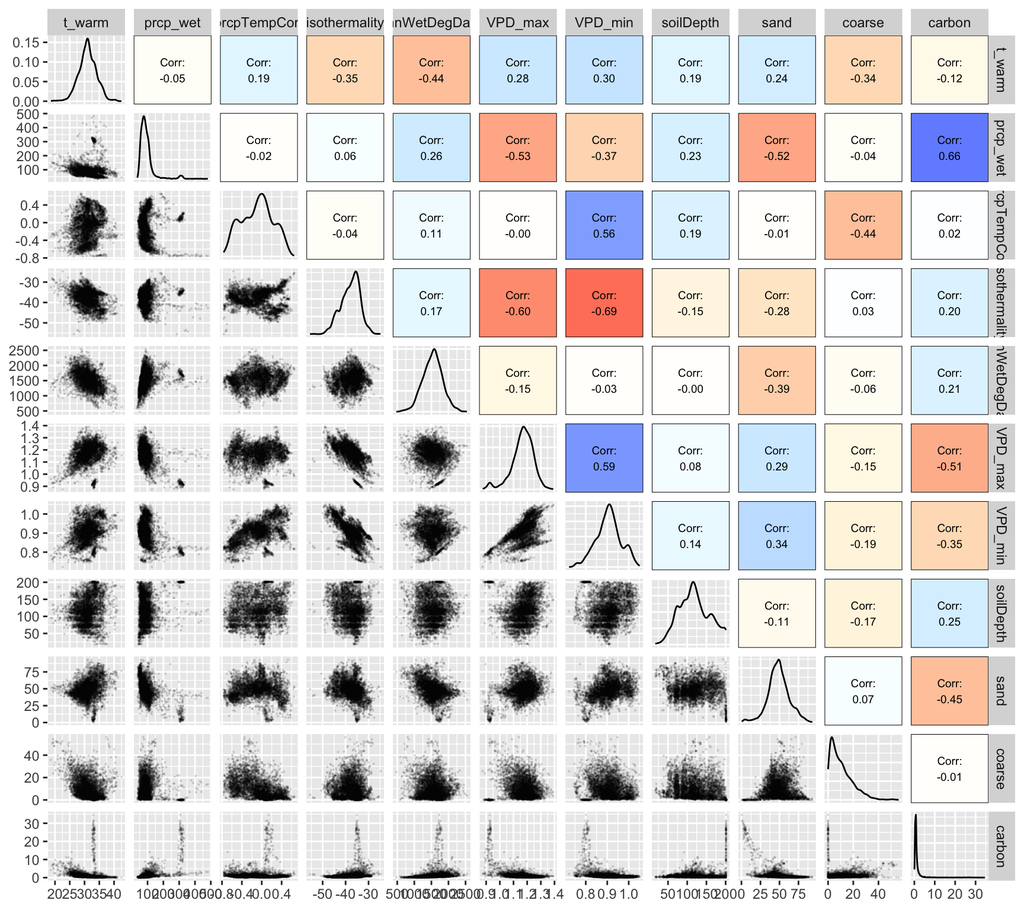

### Forests

First, get data just for forest sites (and drop NAs )

```r
## drop observations so we don't have any NAs
datForest <- dat %>%
  select(tmin_meanAnnAvg_CLIM:durationFrostFreeDays_meanAnnAvg_CLIM, tmean_meanAnnAvg_3yrAnom:durationFrostFreeDays_meanAnnAvg_3yrAnom,
         soilDepth:totalAvailableWaterHoldingCapacity, newRegion) %>%
  drop_na() %>%
  filter(newRegion %in% c("eastForest", "westForest")) %>%
  rename("tmin" = tmin_meanAnnAvg_CLIM,
     "tmax" = tmax_meanAnnAvg_CLIM, #1
     "tmean" = tmean_meanAnnAvg_CLIM,
     "prcp" = prcp_meanAnnTotal_CLIM,
     "t_warm" = T_warmestMonth_meanAnnAvg_CLIM,
     "t_cold" = T_coldestMonth_meanAnnAvg_CLIM,
     "prcp_wet" = precip_wettestMonth_meanAnnAvg_CLIM,
     "prcp_dry" = precip_driestMonth_meanAnnAvg_CLIM,
     "prcp_seasonality" = precip_Seasonality_meanAnnAvg_CLIM, #2
     "prcpTempCorr" = PrecipTempCorr_meanAnnAvg_CLIM,  #3
     "abvFreezingMonth" = aboveFreezing_month_meanAnnAvg_CLIM,
     "isothermality" = isothermality_meanAnnAvg_CLIM, #4
     "annWatDef" = annWaterDeficit_meanAnnAvg_CLIM,
     "annWetDegDays" = annWetDegDays_meanAnnAvg_CLIM,
     "VPD_mean" = annVPD_mean_meanAnnAvg_CLIM,
     "VPD_max" = annVPD_max_meanAnnAvg_CLIM, #5
     "VPD_min" = annVPD_min_meanAnnAvg_CLIM, #6
     "VPD_max_95" = annVPD_max_95percentile_CLIM,
     "annWatDef_95" = annWaterDeficit_95percentile_CLIM,
     "annWetDegDays_5" = annWetDegDays_5percentile_CLIM,
     "frostFreeDays_5" = durationFrostFreeDays_5percentile_CLIM,
     "frostFreeDays" = durationFrostFreeDays_meanAnnAvg_CLIM,
     #"soilDepth" = soilDepth, #7
     "clay" = surfaceClay_perc,
     "sand" = avgSandPerc_acrossDepth, #8
     "coarse" = avgCoarsePerc_acrossDepth, #9
     "carbon" = avgOrganicCarbonPerc_0_3cm, #10
     "AWHC" = totalAvailableWaterHoldingCapacity,
     ## anomaly variables
     tmean_anom = tmean_meanAnnAvg_3yrAnom, #15
     tmin_anom = tmin_meanAnnAvg_3yrAnom, #16
     tmax_anom = tmax_meanAnnAvg_3yrAnom, #17
    prcp_anom = prcp_meanAnnTotal_3yrAnom, #18
      t_warm_anom = T_warmestMonth_meanAnnAvg_3yrAnom,  #19
     t_cold_anom = T_coldestMonth_meanAnnAvg_3yrAnom, #20
      prcp_wet_anom = precip_wettestMonth_meanAnnAvg_3yrAnom, #21
      precp_dry_anom = precip_driestMonth_meanAnnAvg_3yrAnom,  #22
    prcp_seasonality_anom = precip_Seasonality_meanAnnAvg_3yrAnom, #23
     prcpTempCorr_anom = PrecipTempCorr_meanAnnAvg_3yrAnom, #24
      aboveFreezingMonth_anom = aboveFreezing_month_meanAnnAvg_3yrAnom, #25
    isothermality_anom = isothermality_meanAnnAvg_3yrAnom, #26
       annWatDef_anom = annWaterDeficit_meanAnnAvg_3yrAnom, #27
     annWetDegDays_anom = annWetDegDays_meanAnnAvg_3yrAnom,  #28
      VPD_mean_anom = annVPD_mean_meanAnnAvg_3yrAnom, #29
      VPD_min_anom = annVPD_min_meanAnnAvg_3yrAnom,  #30
      VPD_max_anom = annVPD_max_meanAnnAvg_3yrAnom,  #31
     VPD_max_95_anom = annVPD_max_95percentile_3yrAnom, #32
      annWatDef_95_anom = annWaterDeficit_95percentile_3yrAnom, #33
      annWetDegDays_5_anom = annWetDegDays_5percentile_3yrAnom ,  #34
    frostFreeDays_5_anom = durationFrostFreeDays_5percentile_3yrAnom, #35
      frostFreeDays_anom = durationFrostFreeDays_meanAnnAvg_3yrAnom #36
     )
```

The following variables were removed due to correlation with other variables:

- ‘frostFreeDays’ and ‘abvFreezingMonth’: cor = .99; chose ‘abvFreezingMonth’
- ‘tmean’ and ‘VPD_mean’: cor = .99; chose ‘VPD_mean’
- ‘abvFreezingMonth’ and ‘frostFreeDays_5’: cor = .96; chose ‘frostFreeDays_5’
- ‘VPD_mean’ and ‘annWatDef_95’: cor = .71; chose ‘annWatDef_95’
- ‘tmin’ and ‘frostFreeDays_5’: cor = .87; chose ‘frostFreeDays_5’
- ‘annWatDef_95’ and ‘annWatDef’: cor = .98; chose ‘annWatDef’
- ‘t_cold’ and ‘frostFreeDays_5’: cor = .97; chose ‘t_cold’ (opposite of function recommendation, but t_cold is easier to calculate)
- ‘annWatDef’ and ‘VPD_max’: cor = .71; chose ‘VPD_max’
- ‘t_cold’ and ‘tmax’: cor = .77; chose ‘tmax’
- ‘VPD_max’ and ‘VPD_max_95’: cor = .92; chose ‘VPD_max_95’
- ‘prcp_dry’ and ‘prcp_seasonality’: cor = .73; chose ‘prcp_seasonality’
- ‘prcp_wet’ and ‘prcp’: cor = .95; chose ‘prcp’
- ‘totalAvailableWaterHoldingCapacity’ and ‘soilDepth’: cor = .82; chose ‘soilDepth’
- ‘tmax’ and ‘t_warm’: cor = .87; chose ‘t_warm’
- ‘annWetDegDays’ and ‘annWetDegDays_5’: cor = .89; chose ‘annWetDegDays’(opposite of function recommendation, but annWetDegDays is easier to calculate)
- ‘sand’ and ‘clay’: cor = .89; chose ‘sand’

The remaining variables that are uncorrelated are shown here:

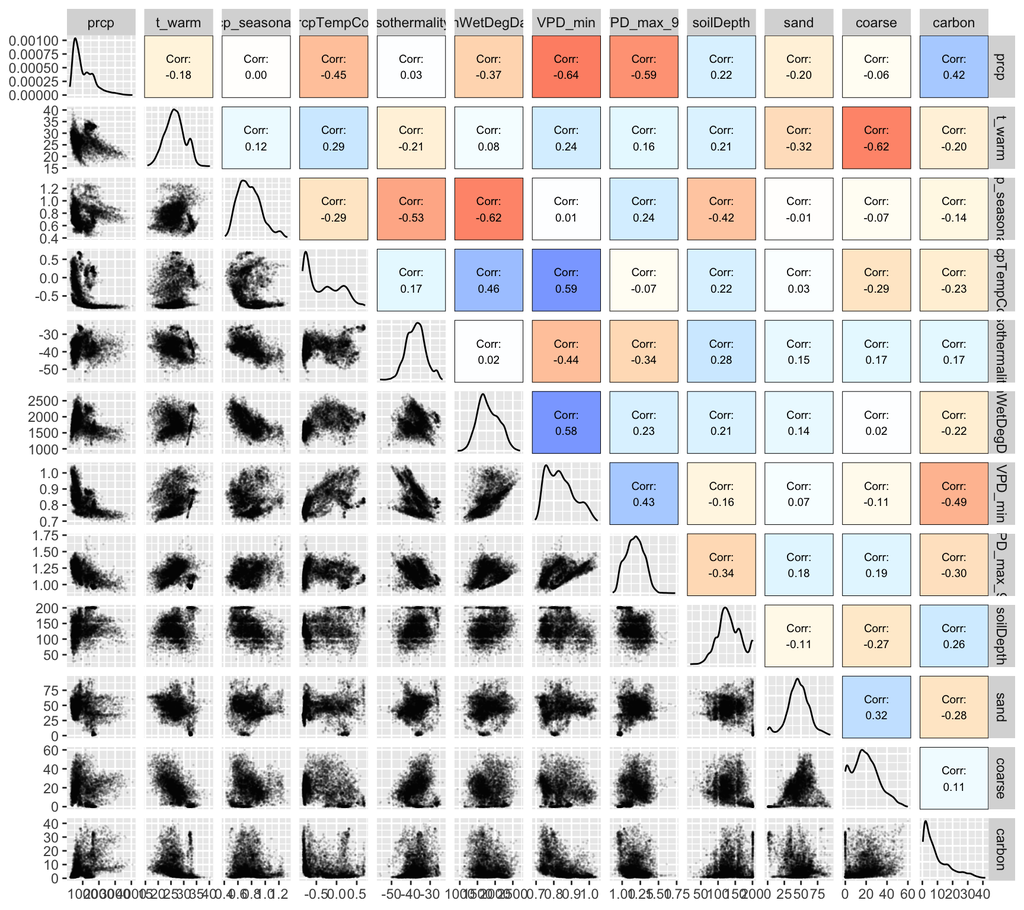

## Then, identify weather anomaly predictors that are uncorrelated with the climate and soils predictors identified above – uniquely for each ecoregion

### Shrubland and Grassland

The remaining variables that are uncorrelated are shown here:

| Climate_And_Soils_Variables | Weather_Anomaly_Variables |
| --- | --- |
| t_warm | tmin_anom |
| prcp_wet | tmax_anom |
| prcpTempCorr | prcp_anom |
| isothermality | t_warm_anom |
| annWetDegDays | t_cold_anom |
| VPD_max | prcp_wet_anom |
| VPD_min | precp_dry_anom |
| soilDepth | prcp_seasonality_anom |
| sand | prcpTempCorr_anom |
| coarse | aboveFreezingMonth_anom |
| carbon | isothermality_anom |
| NA | annWatDef_anom |
| NA | annWetDegDays_anom |
| NA | VPD_min_anom |
| NA | VPD_max_95_anom |
| NA | annWatDef_95_anom |
| NA | annWetDegDays_5_anom |
| NA | frostFreeDays_5_anom |

## Forest

The following variables were removed due to correlation with other variables:

- ‘tmean_anom’ and ‘VPD_mean_anom’: cor = .99; chose ‘VPD_mean_anom’
- ‘VPD_mean_anom’ and ‘VPD_max_anom’: cor = .80; chose ‘VPD_max_anom’
- ‘VPD_max_anom’ and ‘VPD_max_95_anom’: cor = .80; chose ‘VPD_max_95_anom’
- ‘frostFreeDays_5_anom’ and ‘frostFreeDays_anom’: cor = .82; chose ‘frostFreeDays_anom’
- ‘frostFreeDays_anom’ and ‘aboveFreezingMonth_anom’: cor = .82; chose ‘aboveFreezingMonth_anom’

The remaining variables that are uncorrelated are shown below

| Climate_And_Soils_Variables | Weather_Anomaly_Variables |
| --- | --- |
| prcp | tmin_anom |
| t_warm | tmax_anom |
| prcp_seasonality | prcp_anom |
| prcpTempCorr | t_warm_anom |
| isothermality | t_cold_anom |
| annWetDegDays | prcp_wet_anom |
| VPD_min | precp_dry_anom |
| VPD_max_95 | prcp_seasonality_anom |
| soilDepth | prcpTempCorr_anom |
| sand | aboveFreezingMonth_anom |
| coarse | isothermality_anom |
| carbon | annWatDef_anom |
| NA | annWetDegDays_anom |
| NA | VPD_min_anom |
| NA | VPD_max_95_anom |
| NA | annWatDef_95_anom |
| NA | annWetDegDays_5_anom |